# Assignment in *Research Methods for Intelligent Systems, TRIS22*

Prepared by Marcel Bollmann, 2022

## Dataset

This dataset was compiled by Kamil Pytlak based on data from the US-American Centers for Disease Control and Prevention (CDC). It contains survey data from 2020 about the health status of adults in the USA, particularly with regards to whether they ever suffered from heart disease & what potential risk factors for this they might have. We are using a small, sampled subset of the full dataset here, loaded by the following code cell:

```python
import pandas as pd
df = pd.read_csv("data/heart_2020_subset.csv")
df.head()
```

|  | HeartDisease | BMI | Sex | Smoking | AlcoholDrinking | AgeCategory |
| --- | --- | --- | --- | --- | --- | --- |
| 0 | No | 26.58 | Female | No | No | 18-24 |
| 1 | No | 22.63 | Female | No | No | 18-24 |
| 2 | No | 19.01 | Female | No | No | 18-24 |
| 3 | No | 23.21 | Female | No | Yes | 18-24 |
| 4 | No | 21.95 | Female | Yes | No | 18-24 |

Explanation of the columns in this dataset:

- "HeartDisease": contains "Yes" or "No" depending on whether the participant ever suffered from heart disease
- "BMI": contains the body mass index of the participant
- "Sex": contains the sex of the participant as either "Male" or "Female"
- "Smoking": contains "Yes" or "No" depending on whether the participant is a regular smoker
- "AlcoholDrinking": contains "Yes" or "No" depending on whether the participant is a regular alcohol drinker
- "AgeCategory": contains the age bracket of the participant

## Part 1: Data Visualization

Visualize how the incidence of heart disease varies by the two variables "AgeCategory" and "Sex". In other words, what proportion of survey participants, by age group and sex, reported suffering from heart disease?

Your task is to:

1. Decide on an appropriate plot type.
2. Write code that produces the plot from the dataset given above.
3. Make sure the plot communicates the data well, by making deliberate choices on colors, labels, and other styling/layout elements.

```python
## Provide solution here. Add as many code and Markdown blocks as you need.
import matplotlib.pyplot as plt
import numpy as np
```

```python
# Calculate total numbers of samples for female and male
df1_female_total = df[df['Sex'] == 'Female'].groupby(['AgeCategory'])['HeartDisease'].count().to_frame()
df1_male_total = df[df['Sex'] == 'Male'].groupby(['AgeCategory'])['HeartDisease'].count().to_frame()
```

```python
# Calculate total numbers of patients for female and male
df1_female_yes = df[(df["HeartDisease"] == "Yes") & (df['Sex'] == 'Female')].groupby(['AgeCategory','Sex'])['HeartDisease'].count().to_frame()
df1_male_yes = df[(df["HeartDisease"] == "Yes") & (df['Sex'] == 'Male')].groupby(['AgeCategory','Sex'])['HeartDisease'].count().to_frame()
```

```python
# Merge two dataframes and calcalute disease incidence
df1_female = df1_female_total.merge(df1_female_yes, left_on = ["AgeCategory"], right_on = ["AgeCategory"], suffixes=('_total', '_yes'))
df1_male = df1_male_total.merge(df1_male_yes, left_on = ["AgeCategory"], right_on = ["AgeCategory"], suffixes=('_total', '_yes'))
```

```python
df1_female["incidence"] = df1_female["HeartDisease_yes"]/df1_female["HeartDisease_total"]*100
df1_male["incidence"] = df1_male["HeartDisease_yes"]/df1_male["HeartDisease_total"]*100
```

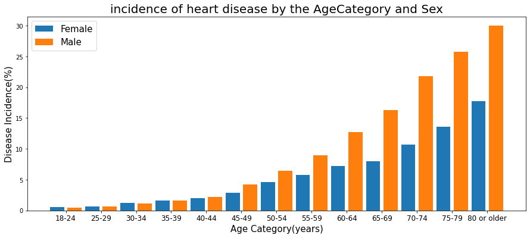

```python
# Graph plotting
plt.figure(figsize=(15,6))

# Create numeric xticks of age groups
age = df["AgeCategory"].unique().tolist()
x_axis = np.arange(len(df1_female))

plt.bar(x=x_axis-0.25, height=df1_female["incidence"], width=0.4, label="Female")
plt.bar(x=x_axis+0.25, height=df1_male["incidence"], width=0.4, label="Male")
plt.xticks(x_axis, age, fontsize=12)
plt.xlabel("Age Category(years)", fontsize=15)
plt.ylabel("Disease Incidence(%)", fontsize=15)
plt.title("incidence of heart disease by the AgeCategory and Sex", fontsize=20)
plt.legend(prop={'size': 15})
```